# Averis AI/Data Science Assesment Solution

# Note

This solution was developed using the following version of R:

```
##                _
## platform       x86_64-w64-mingw32
## arch           x86_64
## os             mingw32
## system         x86_64, mingw32
## status
## major          3
## minor          6.1
## year           2019
## month          07
## day            05
## svn rev        76782
## language       R
## version.string R version 3.6.1 (2019-07-05)
## nickname       Action of the Toes
```

# Libraries

Uncomment this cell to install packages:

```r
# install.packages("tidyverse")
# install.packages("moments")
# install.packages("dbscan")
# install.packages("forecast")
# install.packages("lmtest")
# install.packages("tidytext")
```

# Question 1

## Question

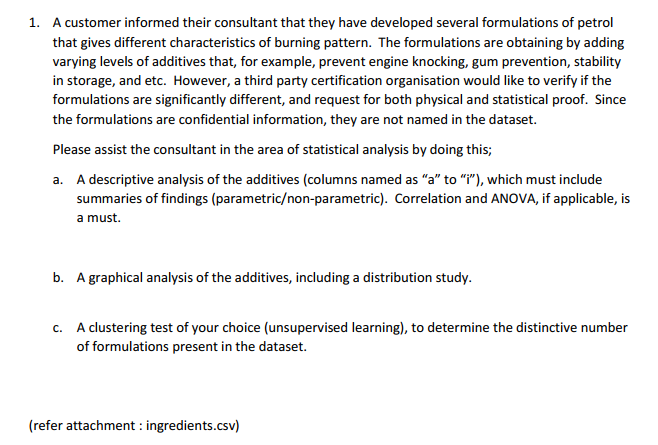

## Solution

Read the ingredients.csv file:

```r
df <- read_csv("../data/ingredient.csv", col_types="ddddddddd")

head(df)
```

| a | b | c | d | e | f | g | h | i |
| --- | --- | --- | --- | --- | --- | --- | --- | --- |
| 1.51735 | 13.02 | 3.54 | 1.69 | 72.73 | 0.54 | 8.44 | 0.00 | 0.07 |
| 1.53125 | 10.73 | 0.00 | 2.10 | 69.81 | 0.58 | 13.30 | 3.15 | 0.28 |
| 1.52300 | 13.31 | 3.58 | 0.82 | 71.99 | 0.12 | 10.17 | 0.00 | 0.03 |
| 1.51768 | 12.56 | 3.52 | 1.43 | 73.15 | 0.57 | 8.54 | 0.00 | 0.00 |
| 1.51813 | 13.43 | 3.98 | 1.18 | 72.49 | 0.58 | 8.15 | 0.00 | 0.00 |
| 1.51721 | 12.87 | 3.48 | 1.33 | 73.04 | 0.56 | 8.43 | 0.00 | 0.00 |

### Solution to Q1a

Some desriptive statistics:

```r
df %>%
  gather(additive, measure) %>%
  group_by(additive) %>%
  summarize(mean = mean(measure),
            median = median(measure),
            `standard deviation` = sd(measure),
            min = min(measure),
            max=max(measure),
            skewness = skewness(measure),
            kurtosis = kurtosis(measure),
            count = n())
```

| additive | mean | median | standard deviation | min | max | skewness | kurtosis | count |
| --- | --- | --- | --- | --- | --- | --- | --- | --- |
| a | 1.51836542 | 1.51768 | 0.003036864 | 1.51115 | 1.53393 | 1.6140150 | 7.789354 | 214 |
| b | 13.40785047 | 13.30000 | 0.816603556 | 10.73000 | 17.38000 | 0.4509917 | 5.953477 | 214 |
| c | 2.68453271 | 3.48000 | 1.442407845 | 0.00000 | 4.49000 | -1.1444648 | 2.571298 | 214 |
| d | 1.44490654 | 1.36000 | 0.499269646 | 0.29000 | 3.50000 | 0.9009179 | 4.984832 | 214 |
| e | 72.65093458 | 72.79000 | 0.774545795 | 69.81000 | 75.41000 | -0.7253173 | 5.871105 | 214 |
| f | 0.49705607 | 0.55500 | 0.652191846 | 0.00000 | 6.21000 | 6.5056358 | 56.392327 | 214 |
| g | 8.95696262 | 8.60000 | 1.423153487 | 5.43000 | 16.19000 | 2.0326774 | 9.498968 | 214 |
| h | 0.17504673 | 0.00000 | 0.497219261 | 0.00000 | 3.15000 | 3.3924309 | 15.222071 | 214 |
| i | 0.05700935 | 0.00000 | 0.097438701 | 0.00000 | 0.51000 | 1.7420068 | 5.572318 | 214 |

One-way ANOVA:

```r
df %>%
  gather(additive, measure) %>%
  aov(measure ~ additive, .) %>%
  summary
```

```
##               Df Sum Sq Mean Sq F value Pr(>F)
## additive       8 943261  117908  168332 <2e-16 ***
## Residuals   1917   1343       1
## ---
## Signif. codes:  0 '***' 0.001 '**' 0.01 '*' 0.05 '.' 0.1 ' ' 1
```

### Solution to Q1b

Boxplot of each additive:

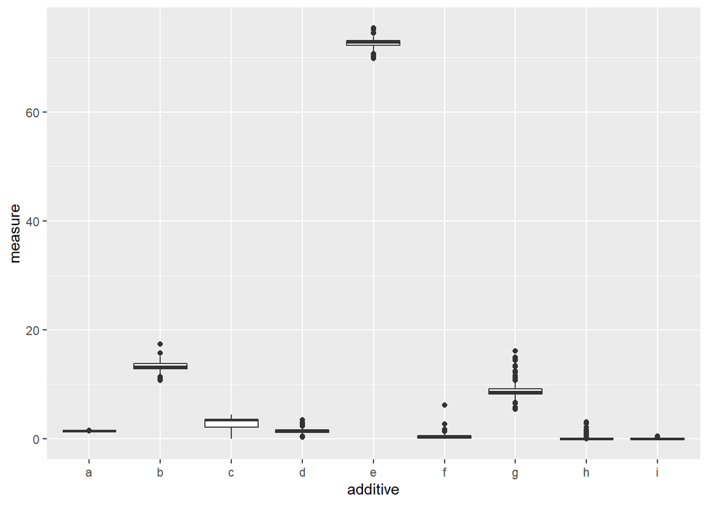

```r
df %>%
  gather(additive, measure) %>%
  ggplot(aes(x=additive, y=measure)) +
  geom_boxplot()
```

The same boxplot but exculding additive “e”:

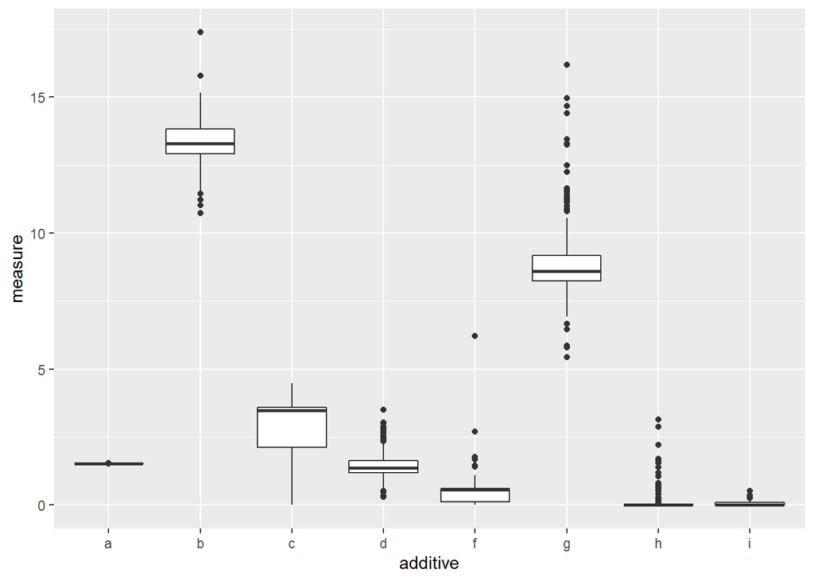

```r
df %>%
  select(-e) %>%
  gather(additive, measure) %>%
  ggplot(aes(x=additive, y=measure)) +
  geom_boxplot()
```

Boxplot of just additive “e”:

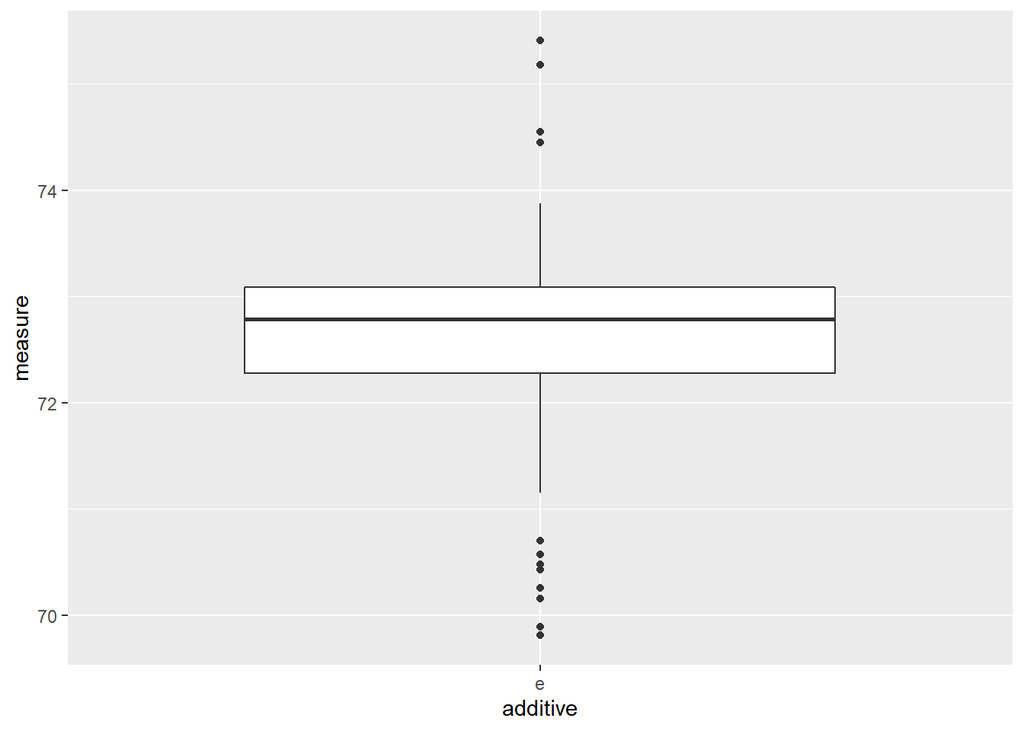

```r
df %>%
  select(e) %>%
  gather(additive, measure) %>%
  ggplot(aes(x=additive, y=measure)) +
  geom_boxplot()
```

A density plot of all the additives:

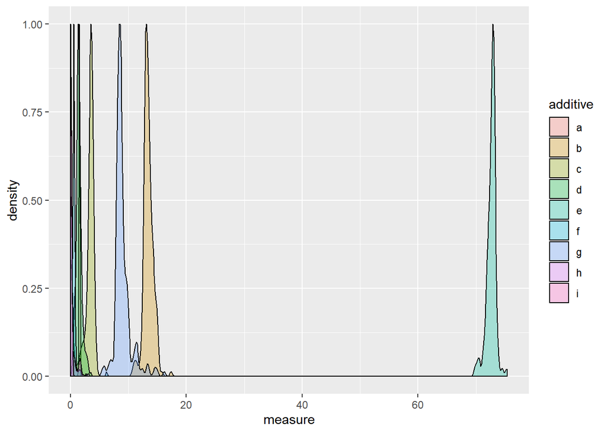

```r
df %>%
  gather(additive, measure) %>%
  ggplot(aes(x=measure, y=..scaled.., group=additive, fill=additive)) +
  geom_density(alpha=0.3) +
  ylab("density")
```

The same density plot but excluding additive “e”:

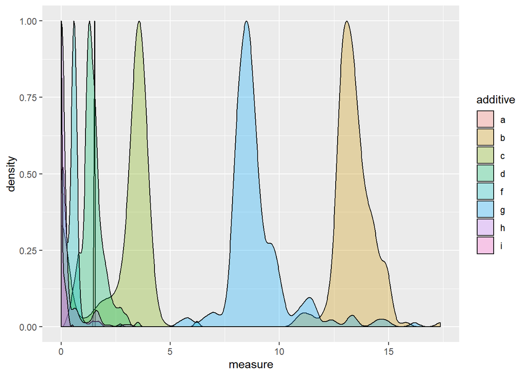

```r
df %>%
  select(-e) %>%
  gather(additive, measure) %>%
  ggplot(aes(x=measure, y=..scaled.., group=additive, fill=additive)) +
  geom_density(alpha=0.3) +
  ylab("density")
```

The graphical analysis gives the same findings as with the descriptive analysis in the previous answer.

### Solution to Q1c

We will use dbscan to determine the number of clusters.

Find out a suitable value for the `eps` parameter using the k-NN plot for k = dim + 1:

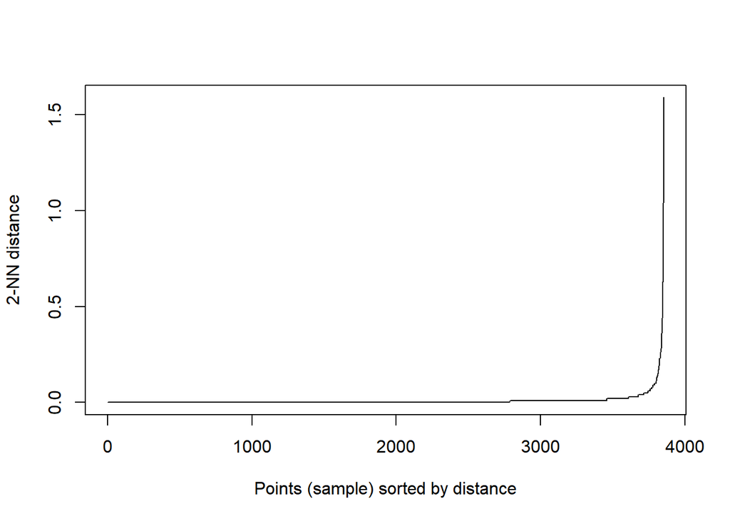

```r
df %>%
  gather(additive, measure) %>%
  select(measure) %>%
  kNNdistplot(k=2)
```

We will set the value for `eps` to 0.2.

```r
cl <- df %>%
  gather(additive, measure) %>%
  select(measure) %>%
  dbscan(eps=0.20, minPts = 10)

cl
```

```
## DBSCAN clustering for 1926 objects.
## Parameters: eps = 0.2, minPts = 10
## The clustering contains 4 cluster(s) and 59 noise points.
##
##    0    1    2    3    4
##   59 1281  210  193  183
##
## Available fields: cluster, eps, minPts
```

Visualize the clusters:

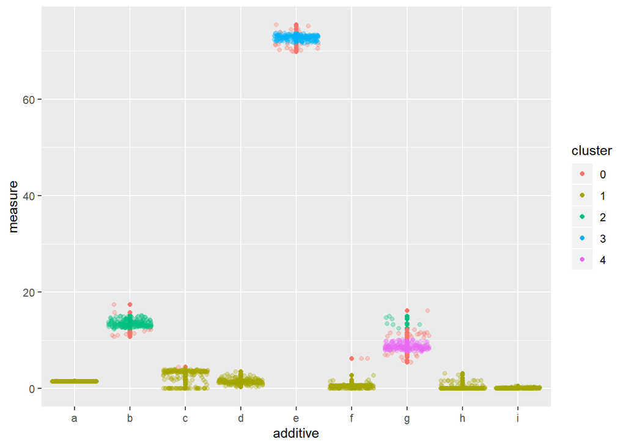

```r
df %>%
  gather(additive, measure) %>%
  mutate(cluster = cl$cluster) %>%
  mutate(cluster = factor(cluster)) %>%
  ggplot(aes(x = additive, y = measure, color = cluster, group = cluster)) +
  geom_point() +
  geom_jitter(alpha = 0.3)
```

This clustering technique found 4 distinct clusters (cluster 0 is noise). This is consistent with the graphical analysis in the previous answer.

# Question 2

## Question

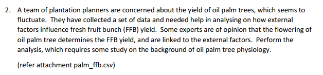

## Solution

### Solution to Q2

Read the data:

```r
df <- read_csv("../data/palm_ffb.csv", col_types="cdddddddd") %>%
  mutate(Date = dmy(Date))

head(df)
```

| Date | SoilMoisture | Average_Temp | Min_Temp | Max_Temp | Precipitation | Working_days | HA_Harvested | FFB_Yield |
| --- | --- | --- | --- | --- | --- | --- | --- | --- |
| 2008-01-01 | 616.4 | 25.30645 | 21.3 | 32.2 | 184.4 | 25 | 777778.4 | 1.62 |
| 2008-02-01 | 568.9 | 26.16552 | 20.9 | 35.1 | 140.2 | 23 | 767988.3 | 1.45 |
| 2008-03-01 | 577.6 | 25.44839 | 21.3 | 32.9 | 280.4 | 25 | 783951.9 | 1.56 |
| 2008-04-01 | 581.1 | 26.90333 | 20.6 | 34.8 | 173.3 | 25 | 788987.1 | 1.39 |
| 2008-05-01 | 545.4 | 27.24194 | 20.9 | 35.0 | 140.6 | 25 | 813659.7 | 1.44 |
| 2008-06-01 | 532.5 | 27.11667 | 21.4 | 35.5 | 182.3 | 24 | 829817.6 | 1.48 |

Plot the `FFB_Yield` trend:

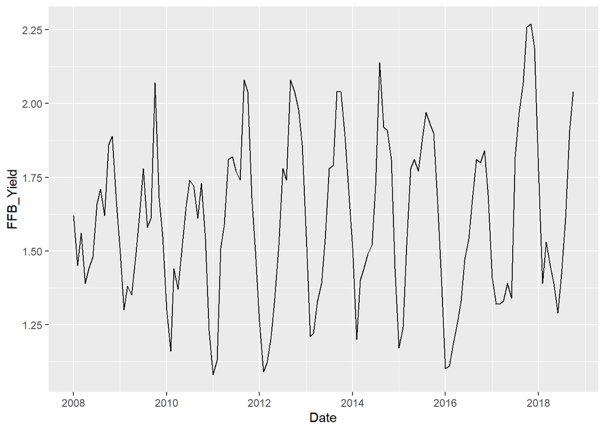

```r
df %>%
  ggplot(aes(x = Date, y = FFB_Yield)) +
  geom_line()
```

Clearly, there is a seasonal component.

Fit an ARIMA with linear regression model:

```r
y <- ts(df$FFB_Yield, start = c(2008, 1), end = c(2018, 10), frequency = 12)


# trial and error results in the following set of variables giving the best model in terms of AIC
x <- df %>%
  select(-Date, -FFB_Yield, -HA_Harvested, -SoilMoisture, -Precipitation, -Min_Temp, -Max_Temp) %>%
  as.matrix()

model <- auto.arima(y, xreg = x)
summary(model)
```

```
## Series: y
## Regression with ARIMA(1,0,0)(2,1,1)[12] errors
##
## Coefficients:
##          ar1    sar1     sar2     sma1  Average_Temp  Working_days
##       0.7166  0.2472  -0.1903  -0.8459       -0.0727        0.0167
## s.e.  0.0645  0.1459   0.1213   0.2010        0.0288        0.0091
##
## sigma^2 estimated as 0.01554:  log likelihood=73.84
## AIC=-133.67   AICc=-132.65   BIC=-114.28
##
## Training set error measures:
##                       ME      RMSE        MAE        MPE     MAPE
## Training set 0.002452675 0.1157051 0.08461976 -0.3755017 5.307308
##                   MASE       ACF1
## Training set 0.4911526 0.07402313
```

Test the model’s coefficients for statistical significance:

```r
coeftest(model)
```

```
##
## z test of coefficients:
##
##                Estimate Std. Error z value  Pr(>|z|)
## ar1           0.7165822  0.0645009 11.1096 < 2.2e-16 ***
## sar1          0.2471600  0.1459137  1.6939   0.09029 .
## sar2         -0.1902972  0.1213430 -1.5683   0.11682
## sma1         -0.8459350  0.2009671 -4.2093 2.561e-05 ***
## Average_Temp -0.0727380  0.0288473 -2.5215   0.01169 *
## Working_days  0.0166702  0.0091392  1.8240   0.06815 .
## ---
## Signif. codes:  0 '***' 0.001 '**' 0.01 '*' 0.05 '.' 0.1 ' ' 1
```

Check the residuals for autocorrelation:

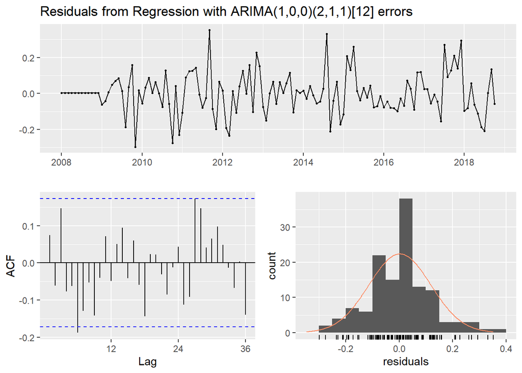

```
##
##  Ljung-Box test
##
## data:  Residuals from Regression with ARIMA(1,0,0)(2,1,1)[12] errors
## Q* = 25.047, df = 18, p-value = 0.1236
##
## Model df: 6.   Total lags used: 24
```

```r
checkresiduals(model)
```

The ACF plot shows only 1 significant spike at lag 6 but the Ljung-Box test does not lead us to conclude (at the 5% significance level) that the residuals are not independently distributed. Also, the other plots show that the residuals look like white noise. Therefore, we can conclude that the residuals are independent.

**Conclusion**:

Given the provided data, the analysis shows that most of the variation in the FFB yield can be explained by the timeseries itself. FFB yield has a 12 month cycle and it’s value at month $n$ is a function of the value at month $n-1$. Accounting for this effect, `Working_days` has a positive effect on FFB yield (increasing FFB yield by 0.02 per additional day) while `Average_Temp` has a negative effect on FFB yield (decreasing FFB yield by 0.07 per additional 1 Celcius) holding all other factors constant.

# Question 3

## Question

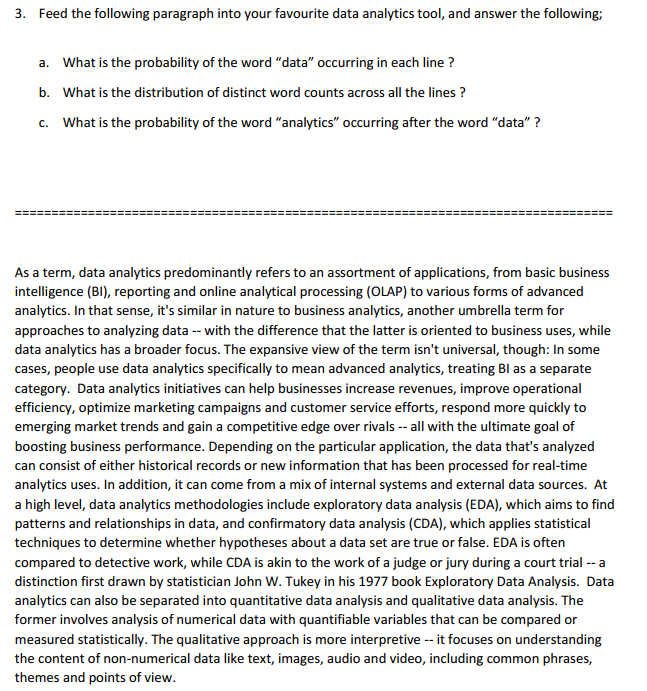

## Solution

Read the data:

```r
df <- read_lines("../data/q3_paragraph.txt") %>%
  enframe(name="line", value="text")
df
```

| line | text |
| --- | --- |
| 1 | As a term, data analytics predominantly refers to an assortment of applications, from basic business |
| 2 | intelligence (BI), reporting and online analytical processing (OLAP) to various forms of advanced |
| 3 | analytics. In that sense, it's similar in nature to business analytics, another umbrella term for |
| 4 | approaches to analyzing data -- with the difference that the latter is oriented to business uses, while |
| 5 | data analytics has a broader focus. The expansive view of the term isn't universal, though: In some |
| 6 | cases, people use data analytics specifically to mean advanced analytics, treating BI as a separate |
| 7 | category. Data analytics initiatives can help businesses increase revenues, improve operational |
| 8 | efficiency, optimize marketing campaigns and customer service efforts, respond more quickly to |
| 9 | emerging market trends and gain a competitive edge over rivals -- all with the ultimate goal of |
| 10 | boosting business performance. Depending on the particular application, the data that's analyzed |

[output cut: 12 more lines]

Calculate total lines:

```r
n_lines = nrow(df)
```

### Solution to Q3a

Calculate probabiliy of the word “data” appearing in a line:

```r
prob_data <- df %>%
  mutate(has_data = str_detect(text, "data")) %>%
  mutate(has_data = as.numeric(has_data)) %>%
  pull(has_data) %>%
  mean
```

The probability of the word “data” occuring in each line is:

```r
# assuming independence
prob_data^n_lines
```

```
## [1] 1.61692e-06
```

### Solution to Q3b

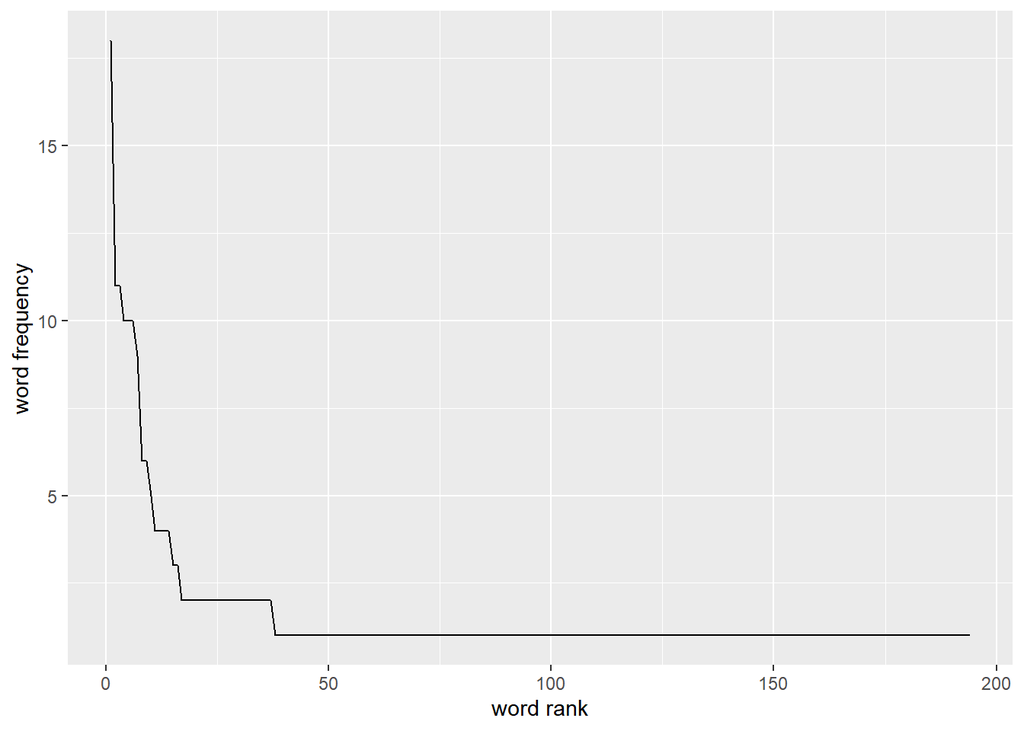

```r
word_count <- df %>%
  unnest_tokens("word", "text") %>%
  count(word, sort=TRUE) %>%
  rowid_to_column("rank")

word_count %>%
  ggplot(aes(x = rank, y = n)) +
  geom_line() +
  xlab("word rank") +
  ylab("word frequency")
```

The distribution of distinct word counts across all the lines follows a approximately a power law.

### Solution to Q3c

```r
# put the paragraph into a single line
para <- df %>%
  unnest_tokens("word", "text") %>%
  group_by("word") %>%
  summarize(text = str_c(word, collapse = " ")) %>%
  select("text")

# check that last word is not data
last_word <- para %>%
  pull(text) %>%
  str_extract("\\b\\w+$")

stopifnot(last_word != "data")

bigrams <- para %>%
  unnest_tokens(bigram, text, token = "ngrams", n = 2)

freq_data_and_analytics <- bigrams %>%
  filter(bigram == "data analytics") %>%
  count %>%
  pull(n)

freq_data <- bigrams %>%
  filter(str_detect(bigram, "^data")) %>%
  count %>%
  pull(n)
```

The probability of the word “analytics” occuring after the word “data” is:

```r
freq_data_and_analytics/freq_data
```

```
## [1] 0.3333333
```